# Web Mining and Applied NLP (44-620)

## Web Scraping and NLP with Requests, BeautifulSoup, and spaCy

### GitHub Repo https://github.com/BenjaminRobin22/Web-Scraping_P6

Perform the tasks described in the Markdown cells below. When you have completed the assignment make sure your code cells have all been run (and have output beneath them) and ensure you have committed and pushed ALL of your changes to your assignment repository.

Every question that requires you to write code will have a code cell underneath it; you may either write your entire solution in that cell or write it in a python file (`.py`), then import and run the appropriate code to answer the question.

```python
# Create and activate a Python virtual environment.
# Before starting the project, try all these imports FIRST
# Address any errors you get running this code cell
# by installing the necessary packages into your active Python environment.
# Try to resolve issues using your materials and the web.
# If that doesn't work, ask for help in the discussion forums.
# You can't complete the exercises until you import these - start early!
# We also import pickle and Counter (included in the Python Standard Library).

from collections import Counter
import pickle
import requests
import spacy
from bs4 import BeautifulSoup
import matplotlib.pyplot as plt

!pip list

print('All prereqs installed.')
```

[output not shown]

[output cut: 80 more lines]

[output not shown]

1. Write code that extracts the article html from https://web.archive.org/web/20210327165005/https://hackaday.com/2021/03/22/how-laser-headlights-work/ and dumps it to a .pkl (or other appropriate file)

```python
import requests
from bs4 import BeautifulSoup
import pickle
import json

# Define the URL of the article
url = "https://web.archive.org/web/20210327165005/https://hackaday.com/2021/03/22/how-laser-headlights-work/"

# Send a GET request to fetch the HTML content
response = requests.get(url)

# Parse the HTML content
soup = BeautifulSoup(response.text, "html.parser")

# Find the article content
article_html = str(soup.find("article"))

# Dump the article HTML to a pickle file
with open("article_html.pkl", "wb") as file:
    pickle.dump(article_html, file)

# Load the article HTML from the pickle file
with open("article_html.pkl", "rb") as file:
    article_html = pickle.load(file)

# Parse the article HTML again to extract text
soup_article = BeautifulSoup(article_html, "html.parser")
article_text = soup_article.get_text(separator="\n")

# Dump the article text to a JSON file
with open("article_content.json", "w", encoding="utf-8") as f:
    json.dump({"content": article_text}, f, ensure_ascii=False, indent=4)

print("Article content extracted and saved to article_content.json")
```

```
Article content extracted and saved to article_content.json
```

2. Read in your article's html source from the file you created in question 1 and print it's text (use `.get_text()`)

```python
import pickle
from bs4 import BeautifulSoup

# Load the article HTML from the pickle file
with open("article_html.pkl", "rb") as file:
    article_html = pickle.load(file)

# Parse the article HTML
soup_article = BeautifulSoup(article_html, "html.parser")

# Extract the text content of the article
article_text = soup_article.get_text(separator="\n")

# Print the text
print(article_text)
```

```
How Laser Headlights Work





                130 Comments




by:


Lewin Day








March 22, 2021
















```

[output cut: 120 more lines]

```
Engineering
,
Featured
,
Laser Hacks
,
Slider
Tagged
laser
,
laser headlight
,
laser headlights
,
light
```

3. Load the article text into a trained `spaCy` pipeline, and determine the 5 most frequent tokens (converted to lower case). Print the common tokens with an appropriate label. Additionally, print the tokens their frequencies (with appropriate labels). Make sure to remove things we don't care about (punctuation, stopwords, whitespace).

```python
import pickle
import spacy
from collections import Counter

# Load the article text from the pickle file
with open("article_html.pkl", "rb") as file:
    article_html = pickle.load(file)

# Parse the article HTML
soup_article = BeautifulSoup(article_html, "html.parser")

# Extract the text content of the article
article_text = soup_article.get_text(separator=" ")

# Load the spaCy English
nlp = spacy.load("en_core_web_sm")

# Process the article text using the spaCy pipeline
doc = nlp(article_text)

# Initialize a Counter to count token frequencies
token_counter = Counter()

# Iterate through tokens in the processed document
for token in doc:
    # Check if the token is alphanumeric and not a stop word this removes punctuation and spaces
    if token.is_alpha and not token.is_stop and not token.is_space:
        # Convert token to lowercase and update counter
        token_counter[token.text.lower()] += 1

# Get the 5 most frequent tokens
most_frequent_tokens = token_counter.most_common(5)

# Print the 5 most frequent tokens
print("Five Most Frequent Tokens:")
for token, frequency in most_frequent_tokens:
    print(f"{token}: {frequency}")

# Print all tokens and their frequencies
print("\nAll Tokens and Their Frequencies:")
for token, frequency in token_counter.items():
    print(f"{token}: {frequency}")
```

```
Five Most Frequent Tokens:
laser: 35
headlights: 19
headlight: 11
technology: 10
led: 10

All Tokens and Their Frequencies:
laser: 35
headlights: 19
work: 2
comments: 1
lewin: 1
day: 3
march: 2
think: 1
onward: 1
automotive: 6
technology: 10
usually: 1
thing: 2
come: 5
mind: 3
engines: 1
fuel: 1
efficiency: 3
switch: 2
electric: 1
power: 3
mean: 1
thousands: 1
engineers: 2
world: 2
working: 1
improve: 1
state: 2
art: 1
lighting: 4
sealed: 2
beam: 7
```

[output cut: 324 more lines]

```
designers: 1
area: 1
concerns: 1
factor: 1
fittings: 1
office: 1
automobiles: 1
regardless: 1
sure: 1
future: 1
posted: 1
hacks: 2
featured: 1
slider: 1
tagged: 1
```

4. Load the article text into a trained `spaCy` pipeline, and determine the 5 most frequent lemmas (converted to lower case). Print the common lemmas with an appropriate label. Additionally, print the lemmas with their frequencies (with appropriate labels). Make sure to remove things we don't care about (punctuation, stopwords, whitespace).

```python
import pickle
import spacy
from collections import Counter

# Load the article text from the pickle file
with open("article_html.pkl", "rb") as file:
    article_html = pickle.load(file)

# Parse the article HTML
soup_article = BeautifulSoup(article_html, "html.parser")

# Extract the text content of the article
article_text = soup_article.get_text(separator=" ")

# Load the spaCy English model
nlp = spacy.load("en_core_web_sm", disable=["parser", "ner"])

# Process the article text using the spaCy pipeline
doc = nlp(article_text)

# Initialize a Counter to count lemma frequencies
lemma_counter = Counter()

# Iterate through tokens in the processed document
for token in doc:
    # Check if the token is alphanumeric and not a stop word
    if token.is_alpha and not token.is_stop and not token.is_space:
        # Convert token to lowercase and update counter with its lemma
        lemma_counter[token.lemma_.lower()] += 1

# Get the 5 most frequent lemmas
most_common_lemmas = lemma_counter.most_common(5)

# Print the 5 most frequent lemmas
print("5 Most Frequent Lemmas:")
for lemma, frequency in most_common_lemmas:
    print(f"{lemma}: {frequency}")

# Print all lemmas and their frequencies
print("\nAll Lemmas and Their Frequencies:")
for lemma, frequency in lemma_counter.items():
    print(f"{lemma}: {frequency}")
```

```
5 Most Frequent Lemmas:
laser: 40
headlight: 28
beam: 12
technology: 10
light: 10

All Lemmas and Their Frequencies:
laser: 40
headlights: 2
work: 3
comments: 1
lewin: 1
day: 4
march: 2
think: 1
onward: 1
automotive: 6
technology: 10
headlight: 28
usually: 1
thing: 3
come: 7
mind: 3
engine: 1
fuel: 1
efficiency: 3
switch: 2
electric: 1
power: 3
mean: 2
thousand: 1
engineer: 2
world: 2
improve: 1
state: 2
art: 1
lighting: 4
seal: 1
beam: 12
```

[output cut: 301 more lines]

```
designer: 1
area: 1
concern: 1
factor: 1
fitting: 1
office: 1
regardless: 1
sure: 1
future: 1
post: 1
hack: 1
featured: 1
hacks: 1
slider: 1
tagged: 1
```

5. Define the following methods:
   - `score_sentence_by_token(sentence, interesting_token)` that takes a sentence and a list of interesting token and returns the number of times that any of the interesting words appear in the sentence divided by the number of words in the sentence
   - `score_sentence_by_lemma(sentence, interesting_lemmas)` that takes a sentence and a list of interesting lemmas and returns the number of times that any of the interesting lemmas appear in the sentence divided by the number of words in the sentence

You may find some of the code from the in class notes useful; feel free to use methods (rewrite them in this cell as well). Test them by showing the score of the first sentence in your article using the frequent tokens and frequent lemmas identified in question 3.

```python
def score_sentence_by_token(sentence, interesting_tokens):
    # Tokenize the sentence into words
    tokens = sentence.split()

    # Initialize a counter for interesting token occurrences
    interesting_token_count = 0

    # Iterate through each word in the sentence
    for word in tokens:
        # Check if the word is in the list of interesting tokens
        if word.lower() in interesting_tokens:
            interesting_token_count += 1

    # Calculate the score by dividing the count of interesting tokens by the total number of tokens
    score = interesting_token_count / len(tokens)
    return score

def score_sentence_by_lemma(sentence, interesting_lemmas):
    # Process the sentence with spaCy
    doc = nlp(sentence)

    # Initialize a counter for interesting lemma occurrences
    interesting_lemma_count = 0

    # Iterate through each token in the processed sentence
    for token in doc:
        # Check if the lemma of the token is in the list of interesting lemmas
        if token.lemma_.lower() in interesting_lemmas:
            interesting_lemma_count += 1

    # Calculate the score by dividing the count of interesting lemmas by the total number of tokens
    score = interesting_lemma_count / len(doc)
    return score

# Example sentences and interesting tokens/lemmas
first_sentence = "Laser headlights offer several advantages over traditional headlights."
interesting_tokens = ["laser", "headlights", "headlight", "technology", "led"]
interesting_lemmas = ["laser", "headlight", "offer", "several", "advantage", "traditional"]

# Calculate scores
token_score = score_sentence_by_token(first_sentence, interesting_tokens)
lemma_score = score_sentence_by_lemma(first_sentence, interesting_lemmas)

# Print scores
print("Token score:", token_score)
print("Lemma score:", lemma_score)
```

```
Token score: 0.25
Lemma score: 0.7777777777777778
```

6. Make a list containing the scores (using tokens) of every sentence in the article, and plot a histogram with appropriate titles and axis labels of the scores. From your histogram, what seems to be the most common range of scores (put the answer in a comment after your code)?

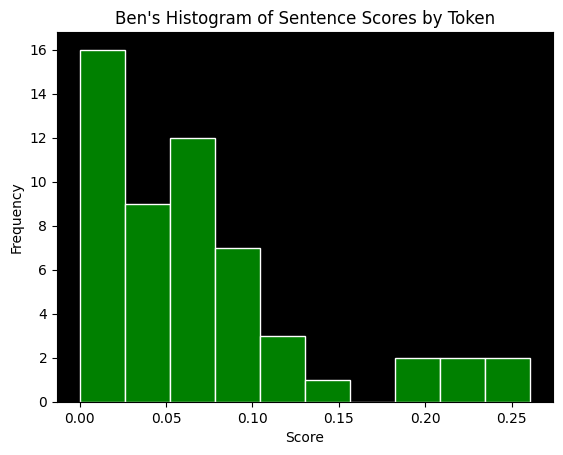

```python
# importing matplotlib for visual
import matplotlib.pyplot as plt

# Split the article text into sentences
sentences = article_text.split('.')

# Generate the list of interesting tokens from the most frequent tokens
interesting_tokens = [token.lower() for token, _ in most_frequent_tokens]

# Calculate scores for each sentence and filter out empty sentences
scores = list(map(lambda sentence: score_sentence_by_token(sentence, interesting_tokens), filter(str.strip, sentences)))

# Plot a histogram of the scores
plt.hist(scores, bins=10, color='green', edgecolor='white')
plt.title("Ben's Histogram of Sentence Scores by Token")
plt.xlabel('Score')
plt.ylabel('Frequency')
plt.gca().set_facecolor('black')
plt.show()
```

## What seems to be the most common range of scores?

A majority of scores sit between .1 and 0. There are very few values outside of this range and they can almost be called outliers. There is a further cluser right at 0.

7. Make a list containing the scores (using lemmas) of every sentence in the article, and plot a histogram with appropriate titles and axis labels of the scores. From your histogram, what seems to be the most common range of scores (put the answer in a comment after your code)?

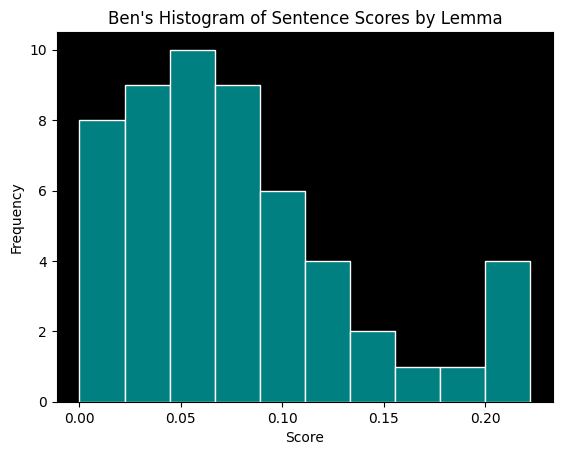

```python
# Split the article text into sentences
sentences = article_text.split('.')

# Generate the list of interesting lemmas from the most frequent lemmas
interesting_lemmas = [lemma.lower() for lemma, _ in most_common_lemmas]

# Calculate scores for each sentence and filter out empty sentences
lemma_scores = list(map(lambda sentence: score_sentence_by_lemma(sentence, interesting_lemmas), filter(str.strip, sentences)))

# Plot a histogram of the lemma scores
plt.hist(lemma_scores, bins=10, color='teal', edgecolor='white')
plt.title("Ben's Histogram of Sentence Scores by Lemma")
plt.gca().set_facecolor('black')
plt.xlabel('Score')
plt.ylabel('Frequency')
plt.show()
```

8. Which tokens and lexems would be ommitted from the lists generated in questions 3 and 4 if we only wanted to consider nouns as interesting words? How might we change the code to only consider nouns? Put your answer in this Markdown cell (you can edit it by double clicking it).

Answer: We can create a list of nouns using a combination of a counter and the token.pos function. We also want to use the exclusion clause that we used above.

```python
# Initialize a Counter to count noun frequencies
noun_counter = Counter()

# Iterate through tokens in the processed document
for token in doc:
    # Check if the token is a noun
    if token.pos_ == 'NOUN':
        # Convert token to lowercase and update counter with its lemma
        noun_counter[token.text.lower()] += 1

# Print the nouns and their frequencies
print("List of Nouns and Their Frequencies:")
for noun, frequency in noun_counter.items():
    print(f"{noun}: {frequency}")
```

```
List of Nouns and Their Frequencies:
technology: 10
headlights: 17
thing: 2
engines: 1
fuel: 1
efficiency: 3
switch: 2
power: 3
front: 3
mind: 2
thousands: 1
engineers: 2
world: 2
state: 2
art: 1
lighting: 4
day: 2
beam: 7
way: 4
designs: 3
regulations: 1
bulbs: 1
halogens: 1
leds: 6
scene: 1
lasers: 5
prototype: 1
laser: 30
assemblies: 1
testing: 1
image: 2
phrase: 1
beams: 5
automobile: 1
light: 6
illumination: 2
spot: 2
distance: 1
eyes: 1
```

[output cut: 117 more lines]

```
standard: 1
norm: 2
home: 2
freedom: 2
appeal: 1
packaging: 1
designers: 1
area: 1
concerns: 1
factor: 1
fittings: 1
office: 1
automobiles: 1
future: 1
hacks: 1
```